# Integration of omics and clinical data of the hormonal, metabolic, inflammatory, and oxidative response in the different macronutrients of the diet

Inference without contrasts

Edmond Geraud

22 de May, 2022

## Load the libraries

```r
> list.of.packages <- c("xlsx", "kableExtra", "dplyr", "ggplot2", "egg", "cowplot",
+     "patchwork", "gridExtra", "UsingR", "car", "lattice", "ggpubr", "ggbreak", "GGally",
+     "reshape2", "ggcorrplot", "corrplot", "ggrepel", "factoextra", "chemometrics",
+     "sparsepca", "vegan", "ca", "ade4", "pls", "OmicsPLS")
> new.packages <- list.of.packages[!(list.of.packages %in% installed.packages()[, "Package"])]  ## check for packages not installed
> if (length(new.packages)) install.packages(new.packages)  ## install packages if necessary
> res <- unlist(lapply(list.of.packages, require, character.only = T))  ## load packages needed for the session
> # if(any(res==F)){
> list.of.packages[which(res == F)]  ## show those package if you have troubles to install.
```

```
character(0)
```

```r
> list.of.bioc.packages <- c("phyloseq", "pcaMethods", "ropls", "mixOmics", "limma",
+     "DESeq2", "edgeR")
> new.packages.bioc <- list.of.packages[!(list.of.bioc.packages %in% installed.packages()[,
+     "Package"])]
> if (length(new.packages.bioc)) BiocManager::install(new.packages.bioc)
> res.bioc <- unlist(lapply(list.of.bioc.packages, require, character.only = T))
> if (any(res.bioc == F)) {
+     list.of.packages[which(res.bioc == F)]  ## show those package if you have troubles to install.
+ }
```

# Funciones

```r
> proces_bacteria <- function(datos,tipo){
+
+   Order <- bacteria_phylum.abs$Order
+   variables_in_bacteria <- general_data[general_data$Orden %in% Order , ]
+   Sample<-variables_in_bacteria$Paciente
+
+
+   if(tipo=="genera"){
+
+     Order <- Order
+
+     X <- datos[-1,-1]
+     X<-apply(X,2,as.numeric)
+     colnames(X) <- datos[1,2:ncol(datos)]
+     rownames(X) <- Sample
+     X.rel <- 100*X/rowSums(X)
+
+
+   } else if(tipo=="phylum"){
+
+     X <- datos[,-c(1:2)]
+     colnames(X) <- colnames(datos)[3:ncol(datos)]
+     rownames(X) <- Sample
+     X.rel<-100*X/rowSums(X)
+   }
+
+   GROUP <-variables_in_bacteria$GROUP
+   SEX <- variables_in_bacteria$SEX
+   OBESE<- variables_in_bacteria$OBESE
+
+   X<-as.data.frame(X)
+   X.rel<-as.data.frame(X.rel)
+
+   X$GROUP<-GROUP
+   X$SEX<-SEX
+   X$OBESE<-OBESE
+
+
+   X.rel$GROUP<-GROUP
+   X.rel$SEX<-SEX
+   X.rel$OBESE<-OBESE
+
+   return(list(abs=X,rel=X.rel))
+
+ }
>
>
> low.count.removal = function(
+                         data, # OTU count data frame of size n (sample) x p (OTU)
+                         percent=0.01 # cutoff chosen
+                         ){
+     keep.otu = which(colSums(data)*100/(sum(colSums(data))) > percent)
+     data.filter = data[,keep.otu]
+     return(list(data.filter = data.filter, keep.otu = keep.otu))
+ }
>
> low.count.removal.counts = function(
+                         data, # OTU count data frame of size n (sample) x p (OTU)
+                         abundance=10 # cutoff chosen
+                         ){
+     keep.otu <- which(colSums(data)>abundance)
+     data.filter <-data[,keep.otu]
+     return(list(data.filter = data.filter, keep.otu = keep.otu))
+ }
>
> relative.fn <-function(data){
+
+   return(100*data/rowSums(data))
+
+ }
>
>
> common.bacteria <- function(datos_i,datos.comunes){
+
+
+   ## retorna los indices con las variables comunes
+
+   interaccion <- interaction(datos.comunes$GROUP,datos.comunes$OBESE)
+   datos.comunes$interaccion <- interaccion
+   grupo <-levels(interaccion)
+   w<-vector(mode="list",length=6)
+   names(w)<-levels(interaccion)
+   for(i in 1:6){
+    w[[names(w)[i]]]<-which(apply(as.matrix(datos_i[
+     rownames(datos_i)%in%
+       datos.comunes[datos.comunes$interaccion==grupo[i],"Paciente"],]),2,function(x) sum(x)==0))
+   }
+
+   w2<-vector(mode="list",length=6)
+   names(w2)<-levels(interaccion)
+   for(i in 1:6){
+    w2[[names(w2)[i]]]<-which(apply(as.matrix(datos_i[
+     rownames(datos_i)%in%
+       datos.comunes[datos.comunes$interaccion==grupo[i],"Paciente"],]),2,function(x) sum(x)>0))
+     }
+
+   w3<-lapply(w2, names)
+   common_variables <-Reduce(intersect,x = w3)
+
+   return(common_variables)
+ }
>
> fn.densidad <- function(datos,fctr){
+   column_var=c("interaccion","variable","value")
+   columnas <- colnames(datos)
+   filas <- rownames(datos)
+   X<-data.frame(apply(datos, 2, as.numeric))
+   colnames(X)<-columnas
+   rownames(X)<-filas
+   X$fctr<-fctr
+   X.melt <- melt(X)
+   colnames(X.melt)<-column_var
+   p<-ggplot(data=X.melt,aes(x=value,color=interaccion))+geom_density()
+
+   return(p)
+ }
>
> fn.boxplot<-function(datos,fctr){
+   column_var=c("interaccion","variable","value")
+   columnas <- colnames(datos)
+   filas <- rownames(datos)
+   X<-data.frame(apply(datos, 2, as.numeric))
+   colnames(X)<-columnas
+   rownames(X)<-filas
+   X$fctr<-fctr
+   X.melt <- melt(X)
+   colnames(X.melt)<-column_var
+
+   p<-ggplot(X.melt,aes(x=interaccion,y=value,fill=interaccion))+geom_boxplot()+theme(axis.text.x = element_text(angle = 90, vjust = 0.5, hjust=1))
+   return(p)
+ }
>
>
> graphPCA.methods <- function(datos,datos.common,varianzas){
+
+
+   sujetos <-as.data.frame(datos)
+   sexo<-datos.common$GROUP
+   obesidad<-datos.common$OBESE
+   colnames(sujetos)<-c("PC1","PC2")
+   p1<-ggplot(sujetos,aes(x=PC1, y=PC2)) +
+      geom_hline(yintercept = 0, color = "gray70") +
+      geom_vline(xintercept = 0, color = "gray70") +
+      geom_point(aes(color = sexo,shape=obesidad,fill=obesidad), alpha = 0.55, size = 3) +
+      coord_cartesian(xlim = c(min(sujetos[,1]),max(sujetos[,1]))) +
+      scale_color_manual(values=c("black","red","green"))+scale_shape_manual(values=c(17,15))+xlab(paste("PC1",round(varianzas[1],2),"%"))+ylab(paste("PC2",round(varianzas[2],2),"%"))
+   return(p1)
+ }
```

# Cargamos los datos

## Datos clinicos

```r
> general_data <- read.xlsx(file.path(params$folder.data, params$file_general), sheetIndex = 1)
> general_data$SEX <- factor(general_data$SEX, levels = c(0, 2), labels = c("Female",
+     "Male"))
> general_data$OBESE <- factor(general_data$OBESE, levels = c(0, 1), labels = c("No Obese",
+     "Obese"))
> general_data$GROUP <- factor(general_data$GROUP, levels = c(0, 1, 2), labels = c("Female",
+     "PCOS", "Male"))
```

## Datos IP

```r
> IP_file <- file.path(params$folder.data, file = params$file_IP)  ## file path of the data
> IP.tmp <- read.xlsx(IP_file, sheetIndex = 1)
> IP <- IP.tmp[, -7]  # remove the missin values column
> IP$SEX <- factor(IP$SEX, levels = c(0, 2), labels = c("Female", "Male"))
> IP$OBESE <- factor(IP$OBESE, levels = c(0, 1), labels = c("No Obese", "Obese"))
> IP$GROUP <- factor(IP$GROUP, levels = c(0, 1, 2), labels = c("Female", "PCOS", "Male"))
```

## Datos Metaboloma

```r
> metabolome_file <- file.path(params$folder.data, file = params$file_metabolome)  ## file path of the data
> metabolome.tmp <- read.xlsx(metabolome_file, sheetIndex = 1)  # read the data
> metabolites_name <- read.xlsx(metabolome_file, sheetIndex = 2)$Metabolitos  # read the names of the metabolites
> any(is.na(metabolome.tmp))  # there is a row of missing values.
```

```
[1] TRUE
```

```r
> metabolome <- metabolome.tmp[-nrow(metabolome.tmp), ]  ## remove the missing value row
> metabolome$GROUP <- general_data$GROUP  ## add GROUP variable
> metabolome$OBESE <- general_data$OBESE  ## add OBESE variables.
```

## Datos microbioma

```r
> bacteria_phylum.abs <- as.data.frame(read.xlsx(file.path(params$folder.data, params$file_microbiota),
+     sheetIndex = 1))
> bacteria_genera.abs <- as.data.frame(t(read.xlsx(file.path(params$folder.data, params$file_microbiota),
+     sheetIndex = 3)))
> phylum.list <- proces_bacteria(bacteria_phylum.abs, tipo = "phylum")
> genera.list <- proces_bacteria(bacteria_genera.abs, tipo = "genera")
>
> phylum.abs <- phylum.list$abs
> phylum.rel <- phylum.list$rel
> genera.abs <- genera.list$abs
> genera.rel <- genera.list$rel
```

# Preparando los datos para la integracion

```r
> variables_in_bacteria <- general_data[general_data$Orden %in% bacteria_phylum.abs$Order,
+     ]
```

## Datos Clinicos

**NOTE we are going to include also on both levels of integration body measures** We exclude ISI because it is measured after the load of glucose, the mean values, to exclude redundancy of the data, ant the postprandial levels.

```r
> sujetos <- variables_in_bacteria$Paciente
> Clin.tmp <- variables_in_bacteria[, -c(1, 2, 3, 4, 5)]  # get rid off orden, paciente, sex, group and obese
> auc_clin <- colnames(Clin.tmp)[grep("AUC", colnames(Clin.tmp))]
> mean_basal_clin <- colnames(Clin.tmp)[grep("_B$", colnames(Clin.tmp))]
> sog <- colnames(Clin.tmp)[grep("^SO[GLP]", colnames(Clin.tmp))]
> variables_clin <- colnames(Clin.tmp)
> testosterona <- colnames(Clin.tmp)[grep("TEST", colnames(Clin.tmp))]
> interr <- colnames(Clin.tmp)[grep("interaccion", colnames(Clin.tmp))]
> ratio <- colnames(Clin.tmp)[grep("Ratio", colnames(Clin.tmp))]
> w <- c(which(variables_clin %in% auc_clin), which(variables_clin %in% mean_basal_clin),
+     which(variables_clin %in% sog), which(variables_clin %in% testosterona), which(variables_clin %in%
+         interr), which(variables_clin %in% ratio))
> Clin <- Clin.tmp[, -w]
> rownames(Clin) <- sujetos
> colnames(Clin)
```

```
 [1] "EDAD"               "BMI"                "WC"
 [4] "WHR"                "SHBG"               "Total_ESTR"
 [7] "Free_ESTRA"         "hsCRP"              "InsulinaBasal_mean"
[10] "GlucosaBasal_mean"  "HOMAIRmean"         "TGmean"
[13] "COLmean"            "HDLmean"            "LDLmean"
```

## Datos IP

```r
> IP.tmp <- IP[IP$Paciente %in% variables_in_bacteria$Paciente, ]
> redundant_variables <- c("Orden", "Paciente", "SEX", "GROUP", "OBESE", "BMI")
> variables_ip <- colnames(IP.tmp)
> auc_ip <- variables_ip[grep("AUC", variables_ip)]
> mean_ip <- variables_ip[grep("_0$", variables_ip)]
> w <- c(which(variables_ip %in% redundant_variables), which(variables_ip %in% auc_ip),
+     which(variables_ip %in% mean_ip))
> IP.basal <- IP.tmp[, -w]
> rownames(IP.basal) <- sujetos
```

## Datos metaboloma

```r
> metabolome.basal.tmp <- metabolome[metabolome$Order %in% variables_in_bacteria$Orden,
+     ]
> redundant_data_meta <- c("Order", "Sample", "GROUP", "OBESE")
> variables_meta <- colnames(metabolome.basal.tmp)
> mean_meta <- variables_meta[grep("_[GLP]0$", variables_meta)]
> auc_meta <- variables_meta[grep("AU[CG]", variables_meta)]
> w <- c(which(variables_meta %in% redundant_data_meta), which(variables_meta %in%
+     mean_meta), which(variables_meta %in% auc_meta))
> metabolome.basal <- metabolome.basal.tmp[, -w]
> rownames(metabolome.basal) <- sujetos
> colnames(metabolome.basal)
```

```
 [1] "Oxoisocaproic_mean" "Leu_mean"           "Isoleu_mean"
 [4] "Valine_mean"        "Isobutyric_mean"    "Oxoisovaleric_mean"
 [7] "OHbutyric_mean"     "Lactate_mean"       "Alanine_mean"
[10] "Acetate_mean"       "Glycoprot_mean"     "Acetone_mean"
[13] "Gluacid_mean"       "Pyruvate_mean"      "Pyroglu_mean"
[16] "Gln_mean"           "Citrate_mean"       "Asn_mean"
[19] "Creatinine_mean"    "Creatine_mean"      "Lysine_mean"
[22] "Ornithine_mean"     "Choline_mean"       "Carnitine_mean"
[25] "Betaine_mean"       "Glycine_mean"       "Threonine_mean"
[28] "Glycerol_mean"      "Serine_mean"        "Proline_mean"
[31] "BGlucose_mean"      "DGlucose_mean"      "Methys_mean"
[34] "Tyrosine_mean"      "Phe_mean"           "Tryp_mean"
[37] "Formate_mean"
```

# Datos que necesitamos

```r
> pacientes <- variables_in_bacteria$Paciente
```

## Datos microbioma

### Datos genero

```r
> genera.abs.tmp <- genera.abs
> redundant_data_ph <- c("GROUP", "SEX", "OBESE")
> genus.tmp.tmp <- genera.abs.tmp[, -c(ncol(genera.abs.tmp) - 2, ncol(genera.abs.tmp) -
+     1, ncol(genera.abs.tmp))]
> genus <- genus.tmp.tmp[, colSums(genus.tmp.tmp) > 0]
> rownames(genus) <- sujetos
> ## removal of genus unidentified
>
> genus <- genus[, -grep("^ud-", colnames(genus))]
>
> common_genus <- common.bacteria(genus, variables_in_bacteria)
>
> genus <- genus[, common_genus]
```

# Preparando inferencia

Como los disenyos recomiendan hacer la interaccion de los factores y luego hacer contrastes (ver documentacion) ” Initial note: Many users begin to add interaction terms to the design formula, when in fact a much simpler approach would give all the results tables that are desired. We will explain this approach first, because it is much simpler to perform. If the comparisons of interest are, for example, the effect of a condition for different sets of samples, a simpler approach than adding interaction terms explicitly to the design formula is to perform the following steps:”

## Primero visualizamos con graficos de barras via phyloseq

Pero antes removemos aquellas que tienen menos de 10 abundancia

```r
> genus.abs <- low.count.removal.counts(genus, 10)$data.filter
```

# Preparando para la inferencia GENERO

Primero vamos a filtrar las variables comunes por aquellas que tengan una minima abundancia de 10 Preparamos el enteorno phyloseq por si las moscas

```r
> grupo <- variables_in_bacteria$GROUP
> obesos <- factor(gsub(" ", ".", variables_in_bacteria$OBESE))
> interaccion <- factor(paste(obesos, grupo, sep = "_"))
> otumat <- t(genus.abs)
> rownames(otumat) <- paste0("OTU", 1:nrow(otumat))
> colnames(otumat) <- pacientes
> taxmat <- cbind(colnames(genus.abs), interaccion)
> colnames(taxmat) <- c("Genus", "interaccion")
> rownames(taxmat) <- rownames(otumat)
> OTU <- otu_table(otumat, taxa_are_rows = T)
> TAX <- tax_table(taxmat)
> physeq <- phyloseq(OTU, TAX)
```

### Vemos los datos crudos

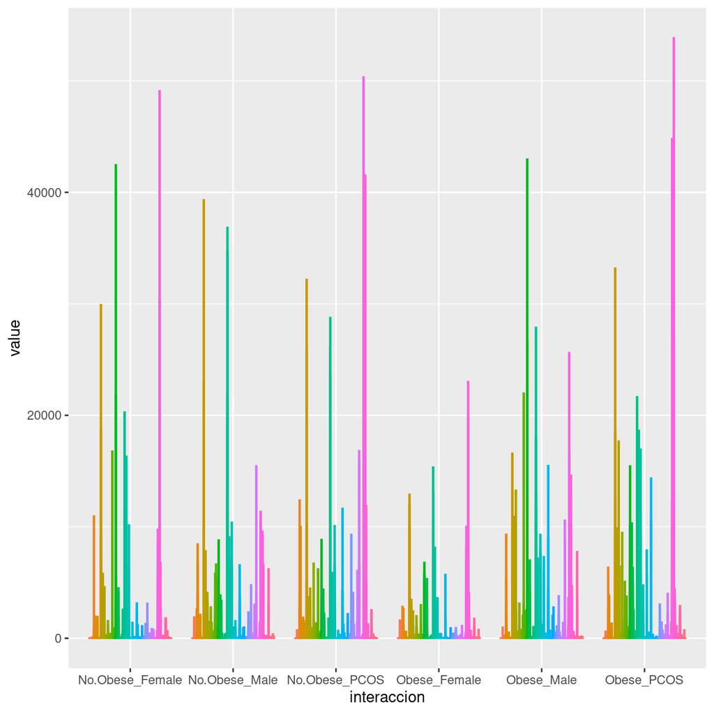

```r
> genus.premelt <- genus.abs
> genus.premelt$interaccion <- interaccion
> genus.melt <- melt(genus.premelt)
> ggplot(genus.melt, aes(x = interaccion, y = value)) + geom_bar(aes(color = variable,
+     fill = variable), stat = "identity", position = position_dodge(0.8)) + theme(legend.position = "none")
```

## Transformaciones

```r
> datos.common <- variables_in_bacteria[, c("GROUP", "OBESE", "Paciente")]
```

### log2(x+1)

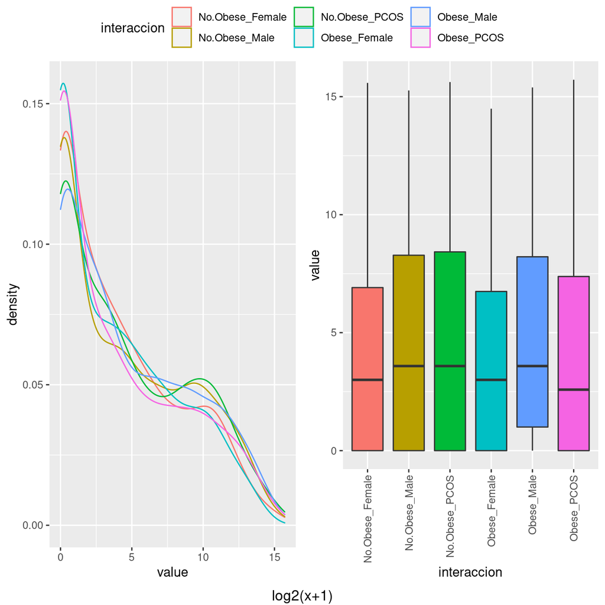

```r
> p1 <- fn.densidad(datos = log2(genus.abs + 1), fctr = interaccion)
> p2 <- fn.boxplot(datos = log2(genus.abs + 1), fctr = interaccion)
> pca.log <- prcomp(t(log2(genus.abs + 1)), center = F, scale. = F)
> pca.var <- 100 * (pca.log$sdev^2/sum(pca.log$sdev^2))
> p3 <- graphPCA.methods(pca.log$rotation[, 1:2], datos.common = datos.common, varianzas = pca.var) +
+     ggtitle("PCA")
> plsda.log <- plsda(log2(genus.abs + 1), Y = interaccion, scale = T)
> plsda.var <- 100 * plsda.log$prop_expl_var$X
> p4 <- graphPCA.methods(datos = plsda.log$variates$X, datos.common = datos.common,
+     varianzas = plsda.var) + ggtitle("PLS-DA")
> p5 <- ggarrange(p1, p2, common.legend = T)
> annotate_figure(p5, bottom = "log2(x+1)")
```

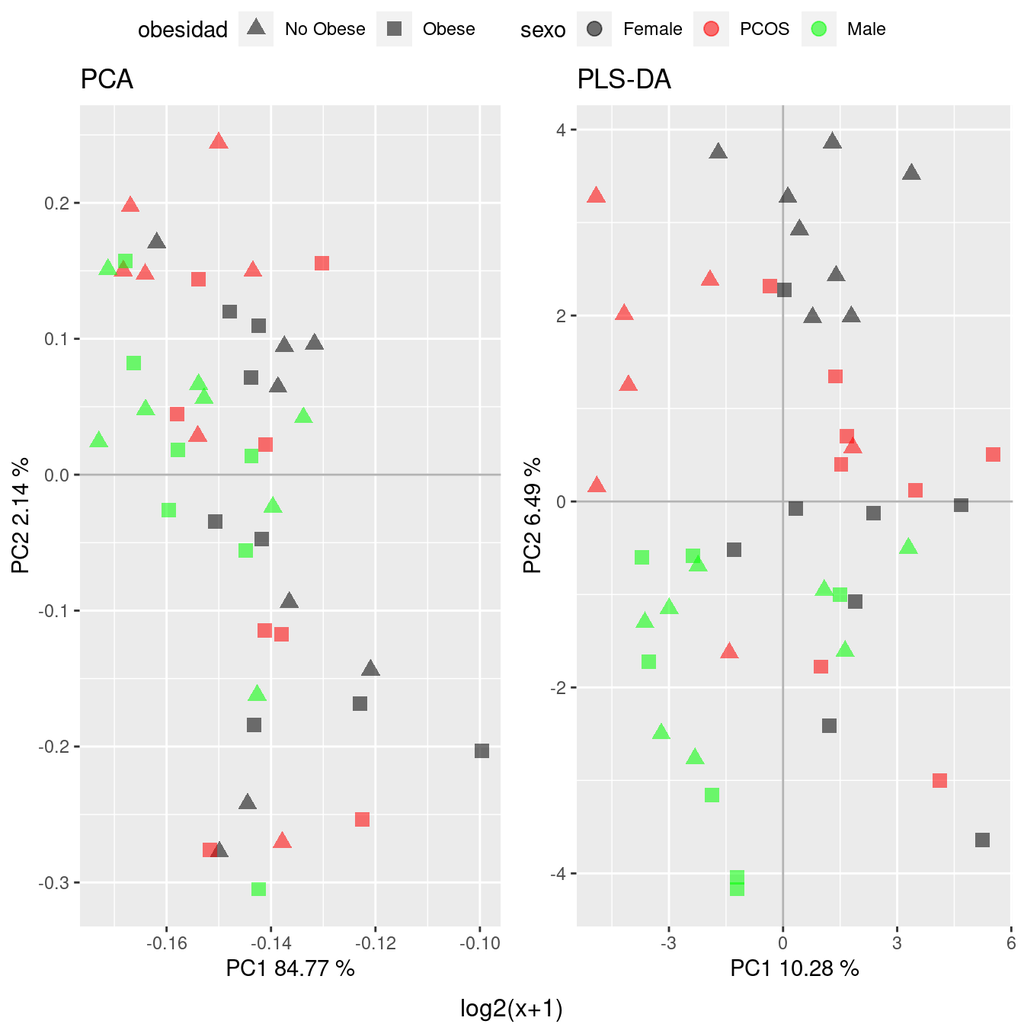

```r
> p6 <- ggarrange(p3, p4, ncol = 2, common.legend = T)
> annotate_figure(p6, bottom = "log2(x+1)")
```

### transformacion (segun mixomics)

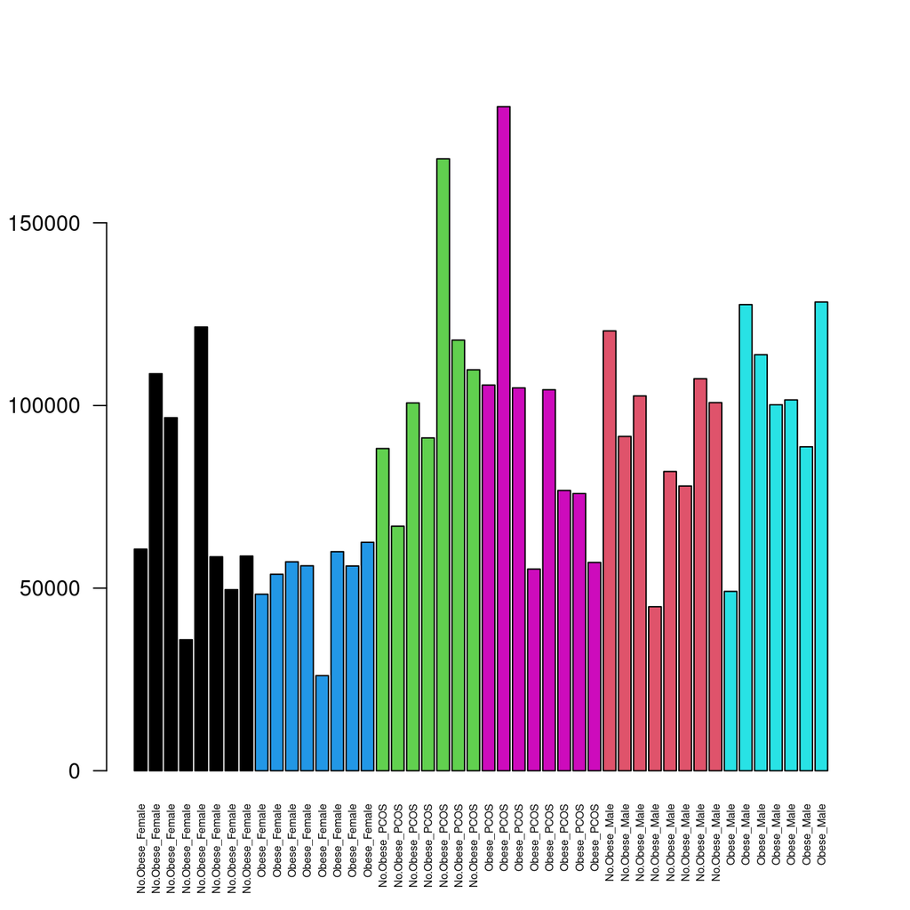

```r
> lib.size <- apply(genus.abs, 1, sum)
> barplot(lib.size, las = 2, names.arg = interaccion, cex.names = 0.5, col = interaccion)
```

#### CLR and ILR

```r
> data.clr <- logratio.transfo(as.matrix(genus.abs), logratio = "CLR", offset = 1)
>
> data.ilr <- logratio.transfo(as.matrix(genus.abs), logratio = "ILR", offset = 1)
```

##### CLR

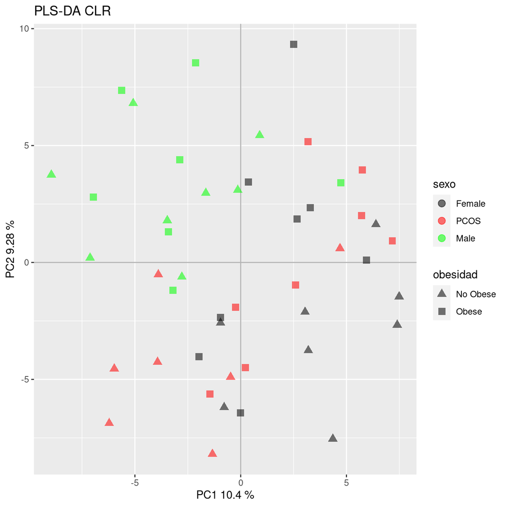

```r
> p1 <- fn.densidad(datos = data.clr, fctr = interaccion)
> p2 <- fn.boxplot(datos = data.clr, fctr = interaccion)
> pca.log <- prcomp(t(data.clr), center = T, scale. = T)
> pca.var <- 100 * (pca.log$sdev^2/sum(pca.log$sdev^2))
> p3 <- graphPCA.methods(pca.log$rotation[, 1:2], datos.common = datos.common, varianzas = pca.var) +
+     ggtitle("PCA")
> pca.spearman <- princomp(cor(t(data.clr), method = "spearman"), fix_sign = T, cor = T)
>
> pca.spearman.scores <- pca.spearman$scores
> pca.spearman.var <- 100 * (pca.spearman$sdev^2/sum(pca.spearman$sdev^2))
> p4 <- graphPCA.methods(pca.spearman.scores[, 1:2], datos.common = datos.common, varianzas = pca.spearman.var) +
+     ggtitle("PCA spearman")
>
>
>
> plsda.log <- plsda(data.clr, Y = interaccion, scale = F)
> plsda.var <- 100 * plsda.log$prop_expl_var$X
> graphPCA.methods(datos = plsda.log$variates$X, datos.common = datos.common, varianzas = plsda.var) +
+     ggtitle("PLS-DA CLR")
```

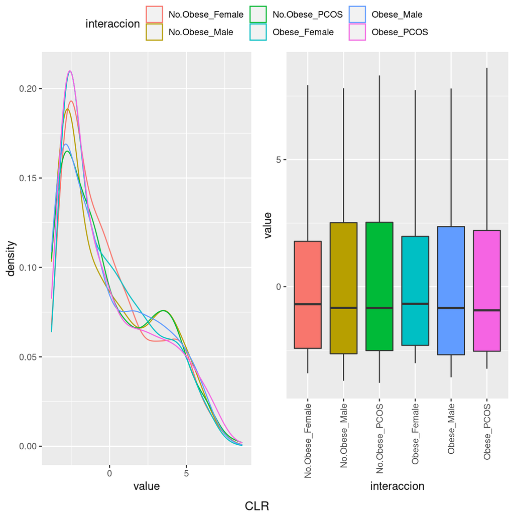

```r
> p7 <- ggarrange(p1, p2, common.legend = T)
> annotate_figure(p7, bottom = "CLR")
```

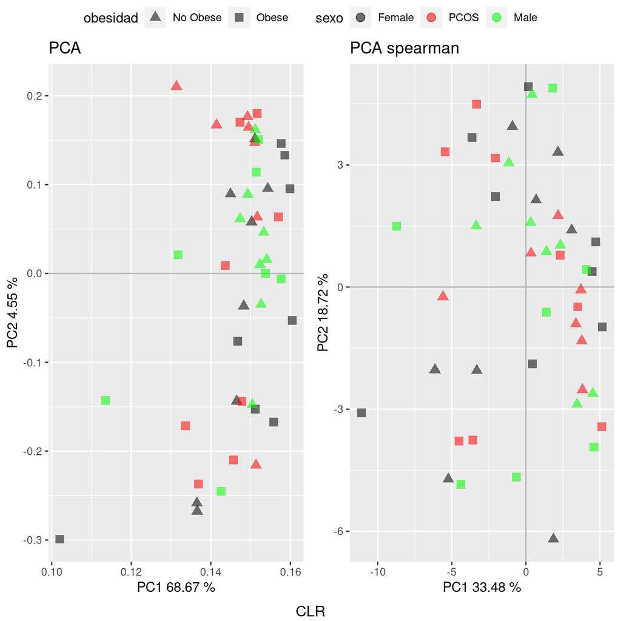

```r
> p8 <- ggarrange(p3, p4, ncol = 2, common.legend = T)
> annotate_figure(p8, bottom = "CLR")
```

##### ILR

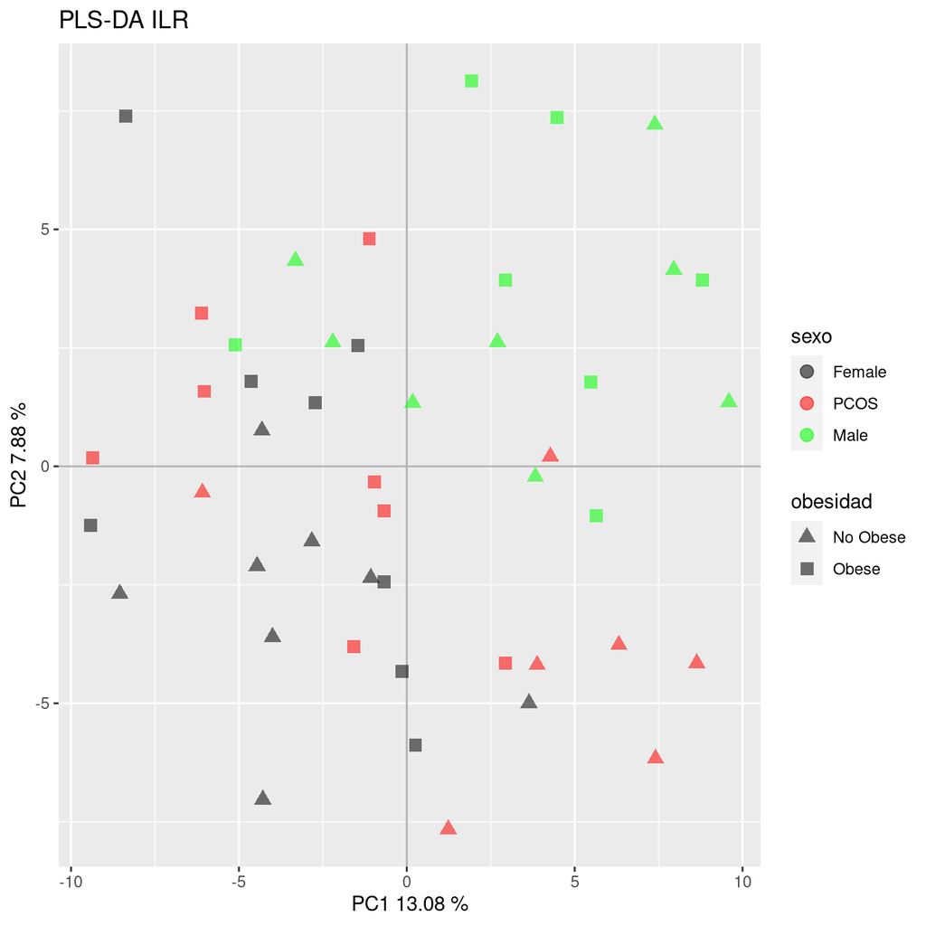

```r
> p1 <- fn.densidad(datos = data.ilr, fctr = interaccion)
> p2 <- fn.boxplot(datos = data.ilr, fctr = interaccion)
> pca.log <- prcomp(t(data.ilr), center = T, scale. = T)
> pca.var <- 100 * (pca.log$sdev^2/sum(pca.log$sdev^2))
> p3 <- graphPCA.methods(pca.log$rotation[, 1:2], datos.common = datos.common, varianzas = pca.var) +
+     ggtitle("PCA")
> pca.spearman <- princomp(cor(t(data.ilr), method = "spearman"), fix_sign = T, cor = T)
>
> pca.spearman.scores <- pca.spearman$scores
> pca.spearman.var <- 100 * (pca.spearman$sdev^2/sum(pca.spearman$sdev^2))
> p4 <- graphPCA.methods(pca.spearman.scores[, 1:2], datos.common = datos.common, varianzas = pca.spearman.var) +
+     ggtitle("PCA spearman")
>
>
>
> plsda.log <- plsda(data.ilr, Y = interaccion, scale = F)
> plsda.var <- 100 * plsda.log$prop_expl_var$X
> graphPCA.methods(datos = plsda.log$variates$X, datos.common = datos.common, varianzas = plsda.var) +
+     ggtitle("PLS-DA ILR")
```

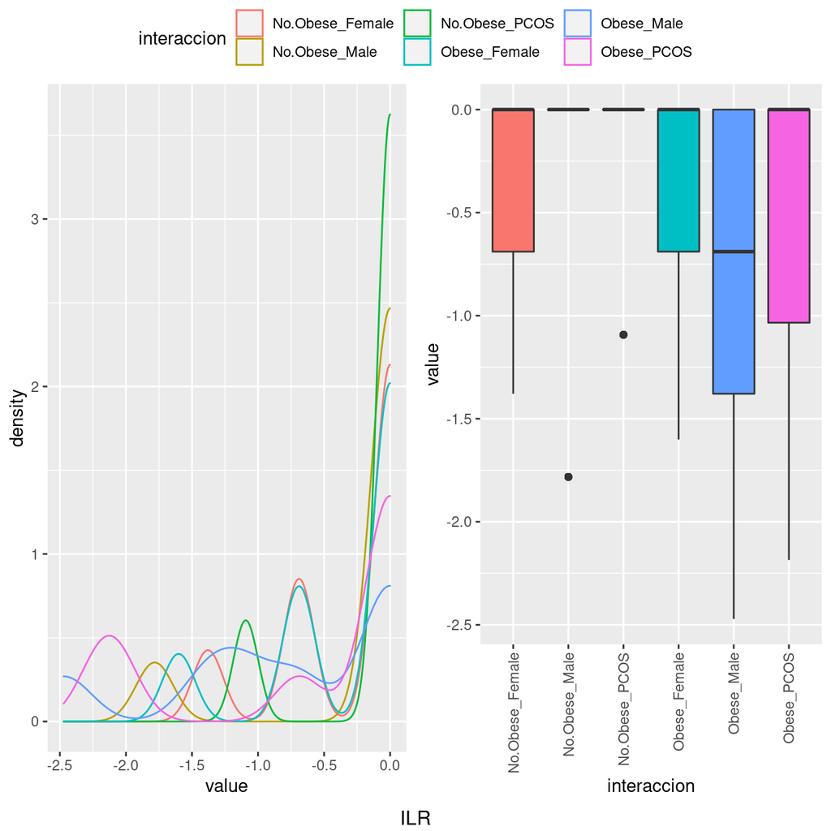

```r
> p7 <- ggarrange(p1, p2, common.legend = T)
> annotate_figure(p7, bottom = "ILR")
```

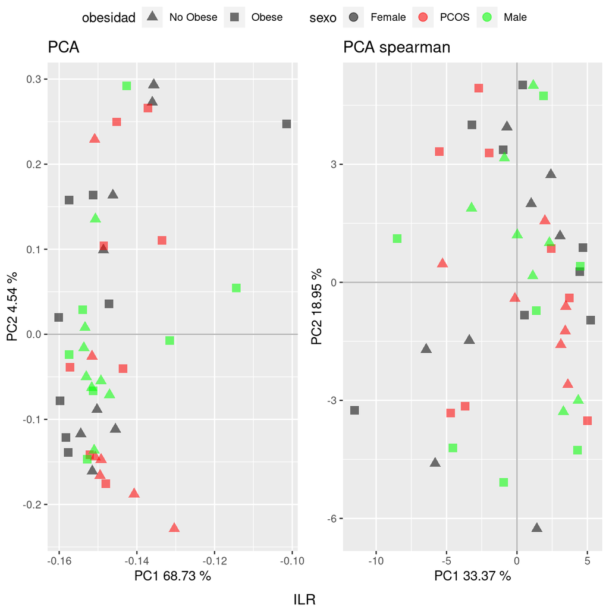

```r
> p8 <- ggarrange(p3, p4, ncol = 2, common.legend = T)
> annotate_figure(p8, bottom = "ILR")
```

### Ahora vamos a probar con limma edgeR sin CLR

#### TMM

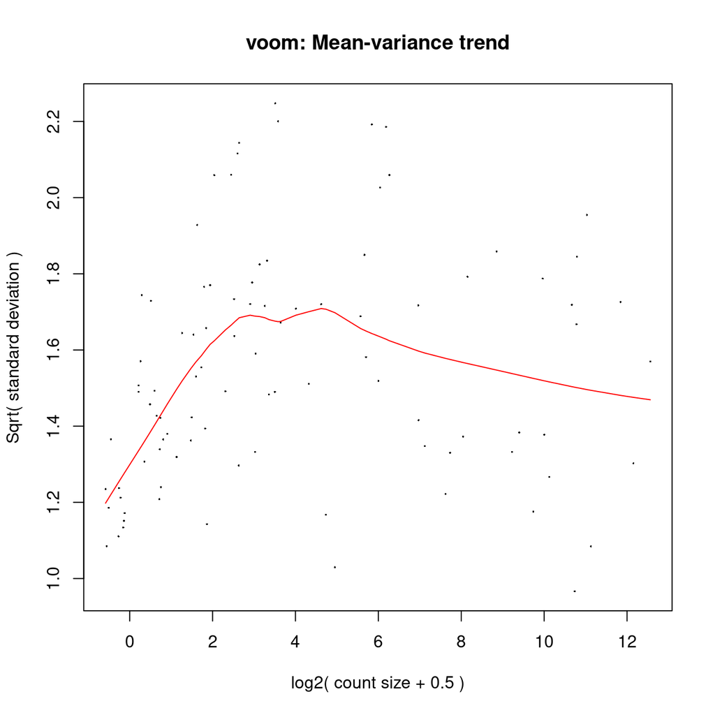

```r
> columnData <- data.frame(interaccion = interaccion)
> rownames(columnData) <- pacientes
> design <- model.matrix(~0 + interaccion)
> dge <- DGEList(counts = t(genus.abs), samples = columnData, group = interaccion)
> nf <- calcNormFactors(dge, refColumn = 1, method = "TMM")
> voom.norm.tmm <- voom(nf, plot = T)
> datos <- t(voom.norm.tmm$E)
> p1 <- fn.densidad(datos = datos, fctr = interaccion)
> p2 <- fn.boxplot(datos = datos, fctr = interaccion)
> pca.log <- prcomp(t(datos), center = T, scale. = T)
> pca.var <- 100 * (pca.log$sdev^2/sum(pca.log$sdev^2))
> p3 <- graphPCA.methods(pca.log$rotation[, 1:2], datos.common = datos.common, varianzas = pca.var) +
+     ggtitle("PCA")
> pca.spearman <- princomp(cor(t(datos), method = "spearman"), fix_sign = T, cor = T)
>
> pca.spearman.scores <- pca.spearman$scores
> pca.spearman.var <- 100 * (pca.spearman$sdev^2/sum(pca.spearman$sdev^2))
> p4 <- graphPCA.methods(pca.spearman.scores[, 1:2], datos.common = datos.common, varianzas = pca.spearman.var) +
+     ggtitle("PCA spearman")
>
>
>
> plsda.log <- plsda(datos, Y = interaccion, scale = F)
> plsda.var <- 100 * plsda.log$prop_expl_var$X
> p5 <- graphPCA.methods(datos = plsda.log$variates$X, datos.common = datos.common,
+     varianzas = plsda.var) + ggtitle("PLS-DA")
>
>
>
> plsda.log.clr <- plsda(datos, Y = interaccion, scale = F, logratio = "CLR")
> plsda.log.clr.var <- 100 * plsda.log.clr$prop_expl_var$X
>
> p6 <- graphPCA.methods(datos = plsda.log.clr$variates$X, datos.common = datos.common,
+     varianzas = plsda.log.clr.var) + ggtitle("PLS-DA CLR")
>
>
> p7 <- ggarrange(p1, p2, common.legend = T)
```

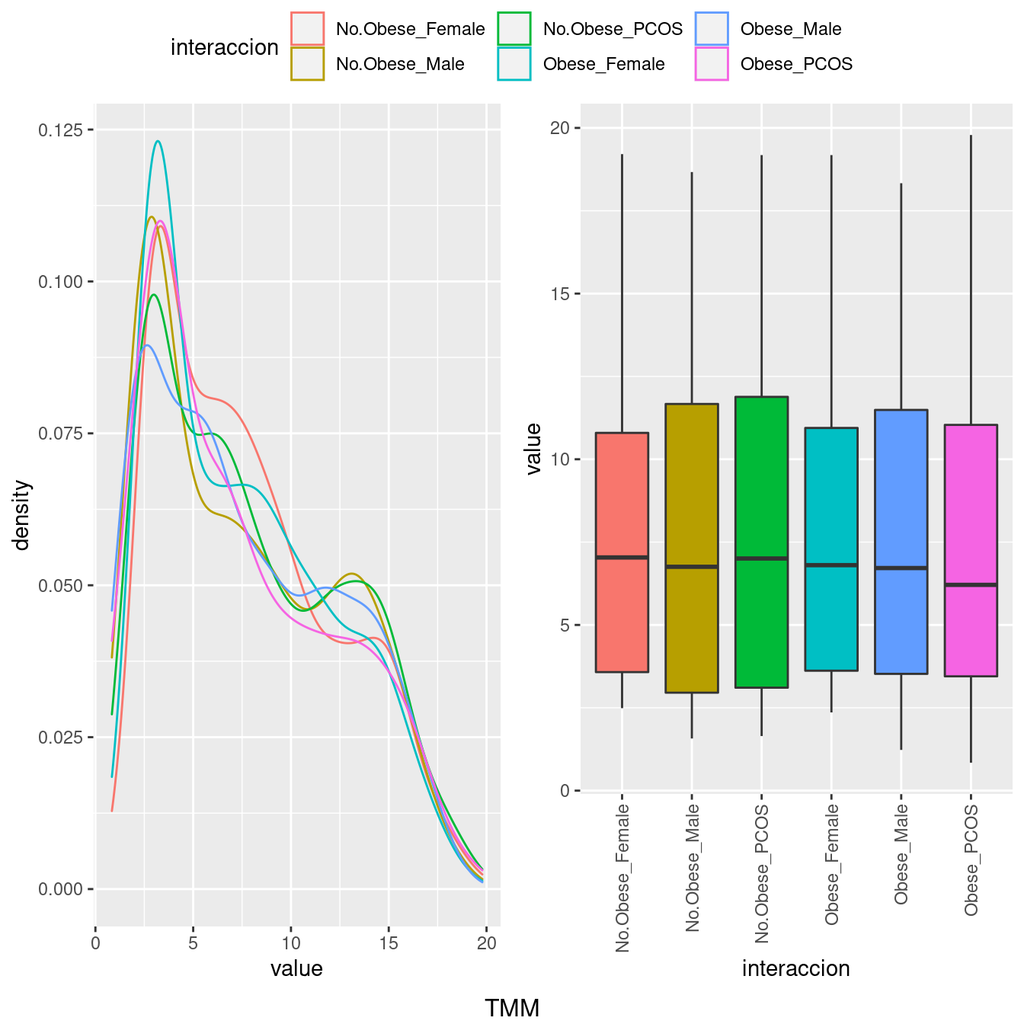

```r
> annotate_figure(p7, bottom = "TMM")
```

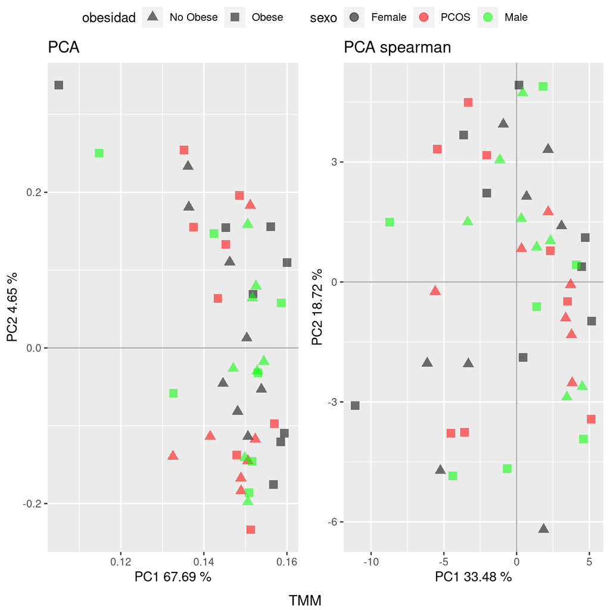

```r
> p8 <- ggarrange(p3, p4, ncol = 2, common.legend = T)
> annotate_figure(p8, bottom = "TMM")
```

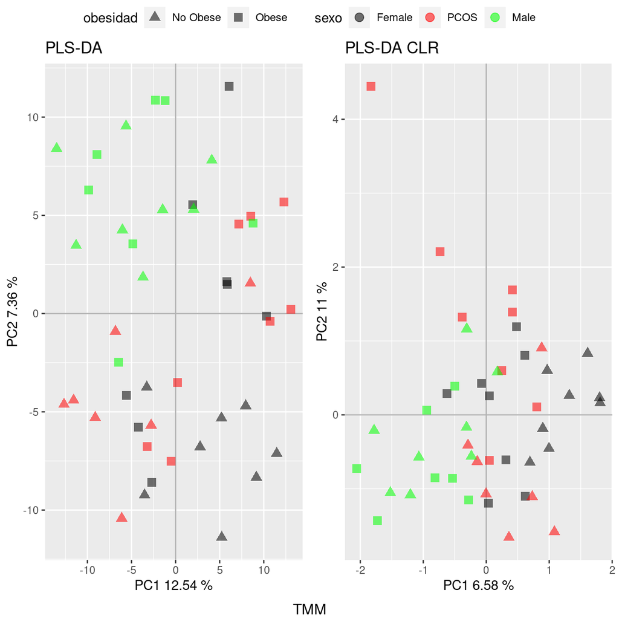

```r
> p9 <- ggarrange(p5, p6, ncol = 2, common.legend = T)
> annotate_figure(p9, bottom = "TMM")
```

#### TMMwsp

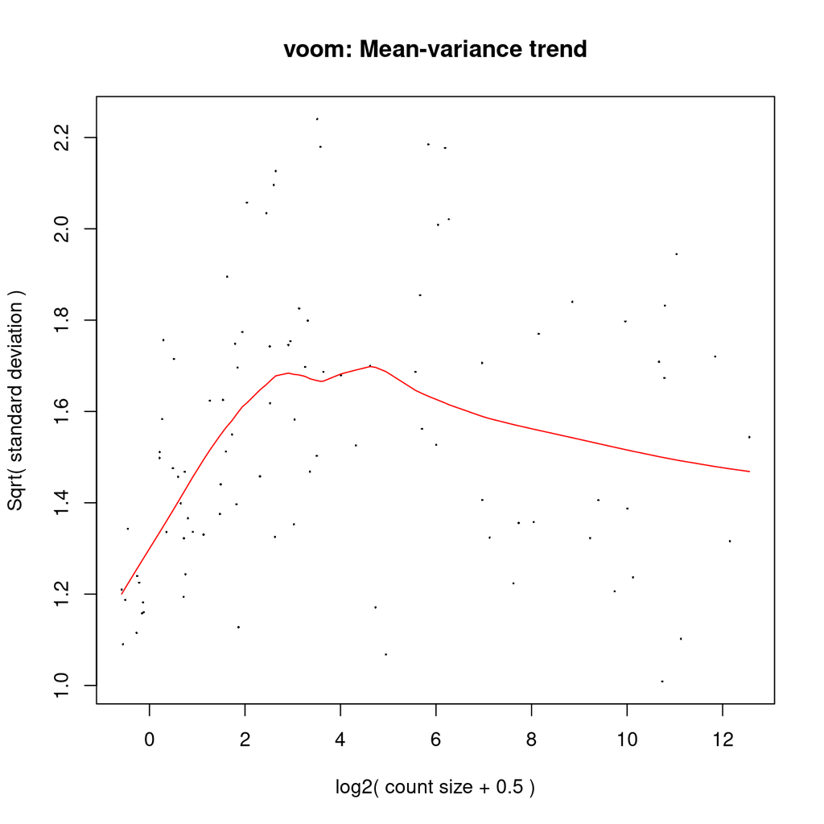

```r
> columnData <- data.frame(interaccion = interaccion)
> rownames(columnData) <- pacientes
> design <- model.matrix(~0 + interaccion)
> dge <- DGEList(counts = t(genus.abs), samples = columnData, group = interaccion)
> nf <- calcNormFactors(dge, refColumn = 1, method = "TMMwsp")
> voom.norm.tmm <- voom(nf, plot = T)
> datos <- t(voom.norm.tmm$E)
> p1 <- fn.densidad(datos = datos, fctr = interaccion)
> p2 <- fn.boxplot(datos = datos, fctr = interaccion)
> pca.log <- prcomp(t(datos), center = T, scale. = T)
> pca.var <- 100 * (pca.log$sdev^2/sum(pca.log$sdev^2))
> p3 <- graphPCA.methods(pca.log$rotation[, 1:2], datos.common = datos.common, varianzas = pca.var) +
+     ggtitle("PCA")
> pca.spearman <- princomp(cor(t(datos), method = "spearman"), fix_sign = T, cor = T)
>
> pca.spearman.scores <- pca.spearman$scores
> pca.spearman.var <- 100 * (pca.spearman$sdev^2/sum(pca.spearman$sdev^2))
> p4 <- graphPCA.methods(pca.spearman.scores[, 1:2], datos.common = datos.common, varianzas = pca.spearman.var) +
+     ggtitle("PCA spearman")
>
>
>
> plsda.log <- plsda(datos, Y = interaccion, scale = F)
> plsda.var <- 100 * plsda.log$prop_expl_var$X
> p5 <- graphPCA.methods(datos = plsda.log$variates$X, datos.common = datos.common,
+     varianzas = plsda.var) + ggtitle("PLS-DA")
>
>
>
> plsda.log.clr <- plsda(datos, Y = interaccion, scale = F, logratio = "CLR")
> plsda.log.clr.var <- 100 * plsda.log.clr$prop_expl_var$X
>
> p6 <- graphPCA.methods(datos = plsda.log.clr$variates$X, datos.common = datos.common,
+     varianzas = plsda.log.clr.var) + ggtitle("PLS-DA CLR")
>
>
> p7 <- ggarrange(p1, p2, common.legend = T)
```

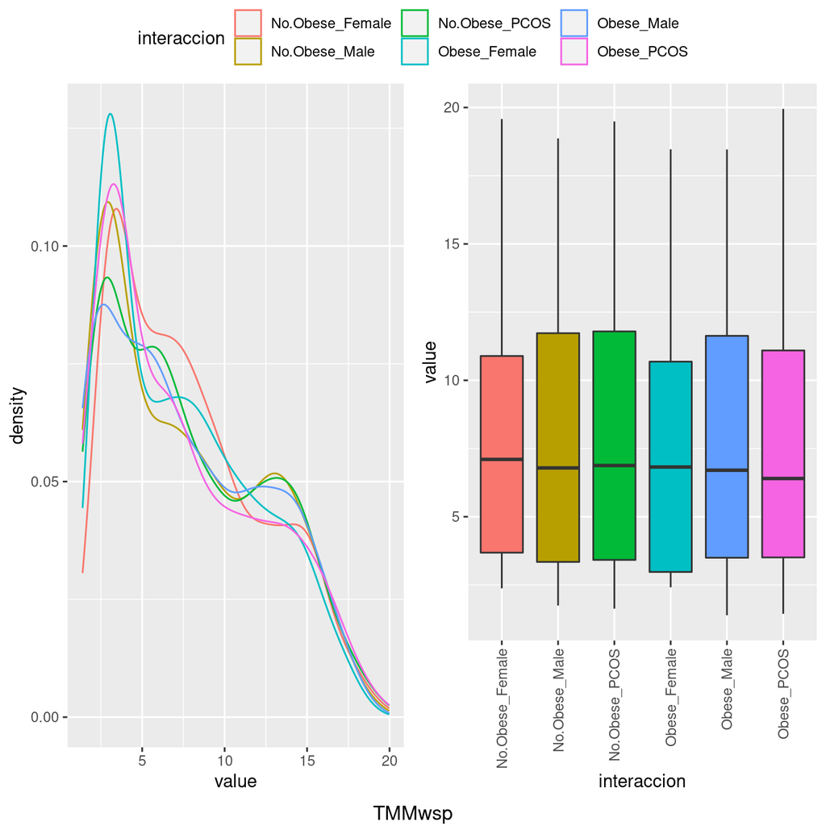

```r
> annotate_figure(p7, bottom = "TMMwsp")
```

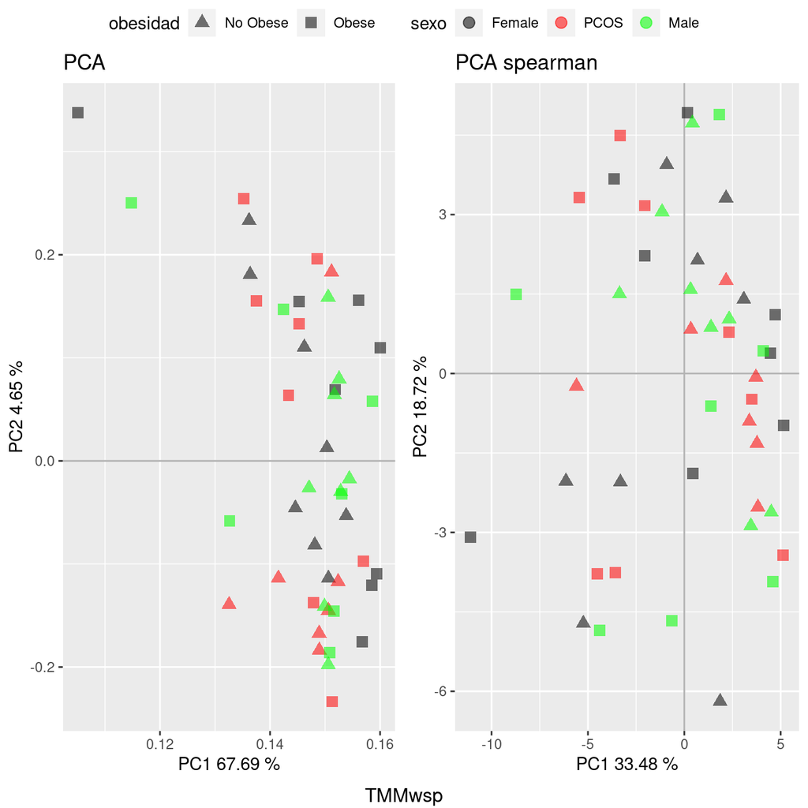

```r
> p8 <- ggarrange(p3, p4, ncol = 2, common.legend = T)
> annotate_figure(p8, bottom = "TMMwsp")
```

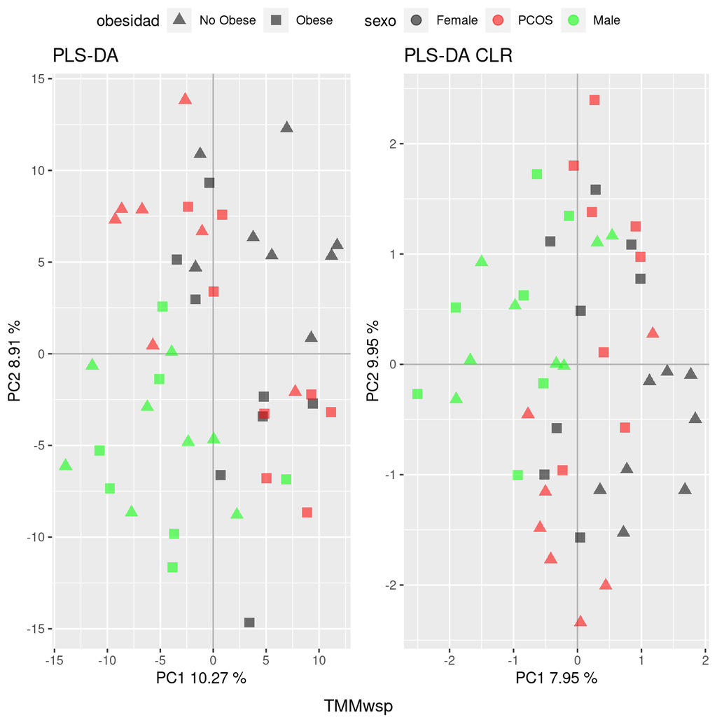

```r
> p9 <- ggarrange(p5, p6, ncol = 2, common.legend = T)
> annotate_figure(p9, bottom = "TMMwsp")
```

#### RLE

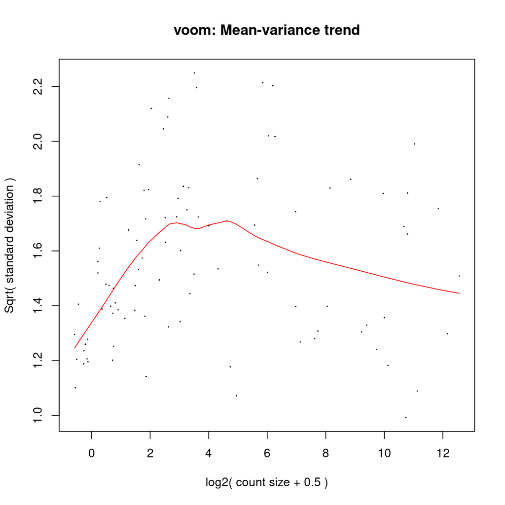

```r
> columnData <- data.frame(interaccion = interaccion)
> rownames(columnData) <- pacientes
> design <- model.matrix(~0 + interaccion)
> dge <- DGEList(counts = t(genus.abs), samples = columnData, group = interaccion)
> nf <- calcNormFactors(dge, refColumn = NULL, method = "RLE")
> voom.norm.tmm <- voom(nf, plot = T)
> datos <- t(voom.norm.tmm$E)
> p1 <- fn.densidad(datos = datos, fctr = interaccion)
> p2 <- fn.boxplot(datos = datos, fctr = interaccion)
> pca.log <- prcomp(t(datos), center = T, scale. = T)
> pca.var <- 100 * (pca.log$sdev^2/sum(pca.log$sdev^2))
> p3 <- graphPCA.methods(pca.log$rotation[, 1:2], datos.common = datos.common, varianzas = pca.var) +
+     ggtitle("PCA")
> pca.spearman <- princomp(cor(t(datos), method = "spearman"), fix_sign = T, cor = T)
>
> pca.spearman.scores <- pca.spearman$scores
> pca.spearman.var <- 100 * (pca.spearman$sdev^2/sum(pca.spearman$sdev^2))
> p4 <- graphPCA.methods(pca.spearman.scores[, 1:2], datos.common = datos.common, varianzas = pca.spearman.var) +
+     ggtitle("PCA spearman")
>
>
>
> plsda.log <- plsda(datos, Y = interaccion, scale = F)
> plsda.var <- 100 * plsda.log$prop_expl_var$X
> p5 <- graphPCA.methods(datos = plsda.log$variates$X, datos.common = datos.common,
+     varianzas = plsda.var) + ggtitle("PLS-DA")
>
>
>
> plsda.log.clr <- plsda(datos, Y = interaccion, scale = F, logratio = "CLR")
> plsda.log.clr.var <- 100 * plsda.log.clr$prop_expl_var$X
>
> p6 <- graphPCA.methods(datos = plsda.log.clr$variates$X, datos.common = datos.common,
+     varianzas = plsda.log.clr.var) + ggtitle("PLS-DA CLR")
>
>
> p7 <- ggarrange(p1, p2, common.legend = T)
```

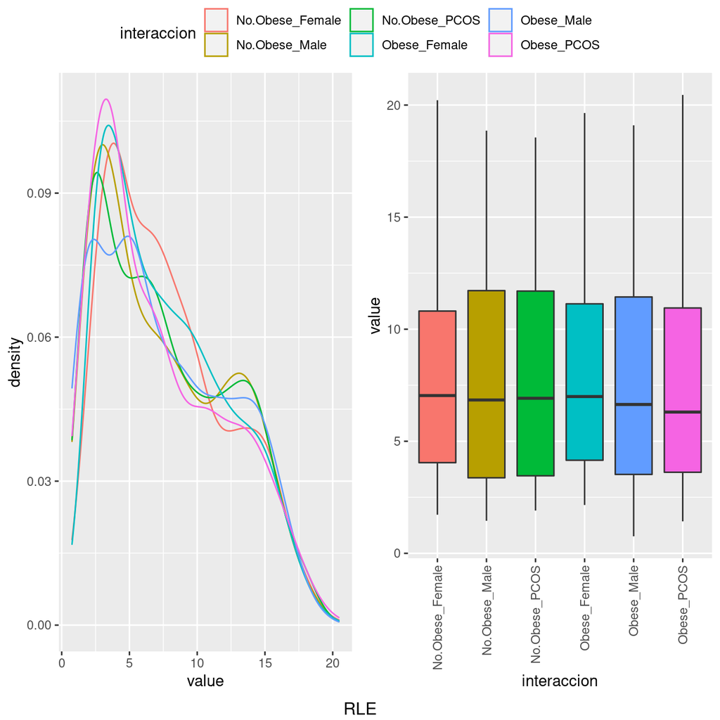

```r
> annotate_figure(p7, bottom = "RLE")
```

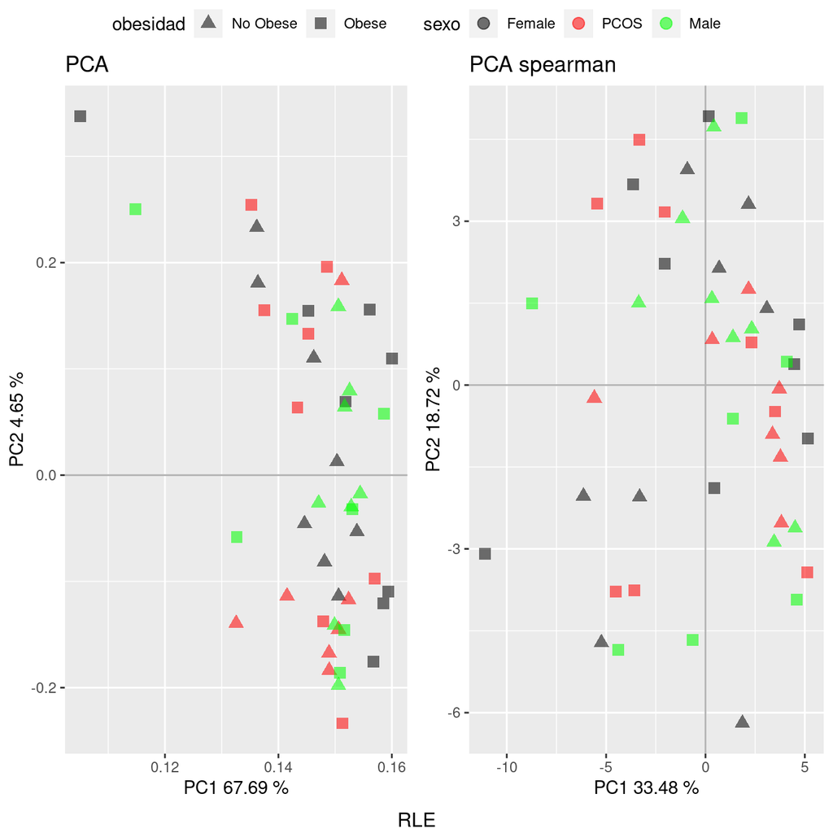

```r
> p8 <- ggarrange(p3, p4, ncol = 2, common.legend = T)
> annotate_figure(p8, bottom = "RLE")
```

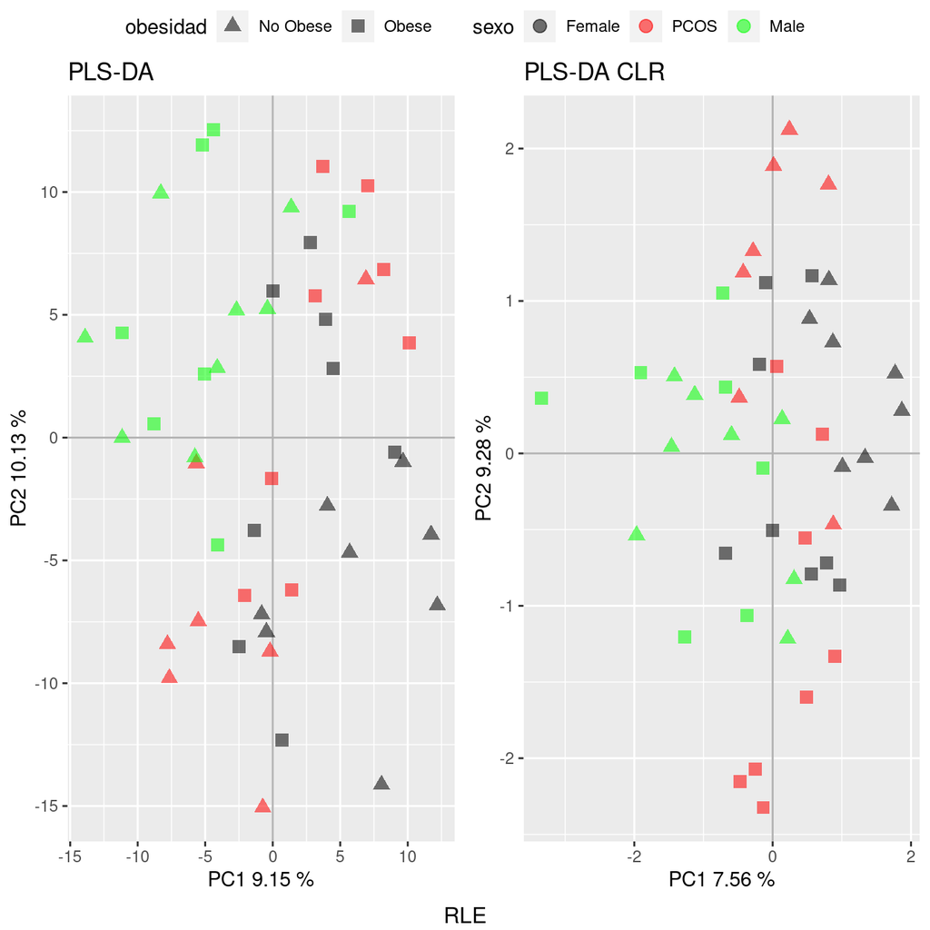

```r
> p9 <- ggarrange(p5, p6, ncol = 2, common.legend = T)
> annotate_figure(p9, bottom = "RLE")
```

#### upperquartile

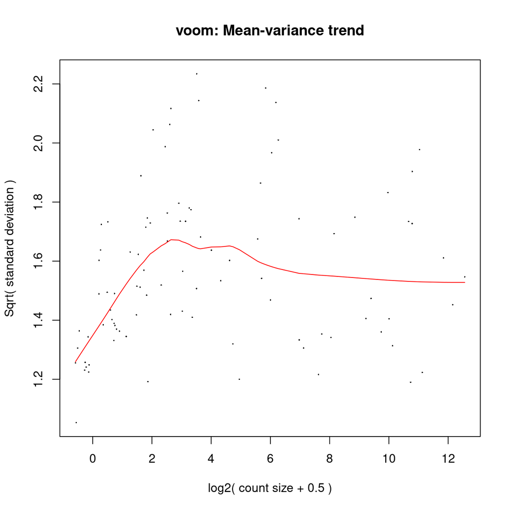

```r
> columnData <- data.frame(interaccion = interaccion)
> rownames(columnData) <- pacientes
> design <- model.matrix(~0 + interaccion)
> dge <- DGEList(counts = t(genus.abs), samples = columnData, group = interaccion)
> nf <- calcNormFactors(dge, refColumn = NULL, method = "upperquartile")
> voom.norm.tmm <- voom(nf, plot = T)
> datos <- t(voom.norm.tmm$E)
> p1 <- fn.densidad(datos = datos, fctr = interaccion)
> p2 <- fn.boxplot(datos = datos, fctr = interaccion)
> pca.log <- prcomp(t(datos), center = T, scale. = T)
> pca.var <- 100 * (pca.log$sdev^2/sum(pca.log$sdev^2))
> p3 <- graphPCA.methods(pca.log$rotation[, 1:2], datos.common = datos.common, varianzas = pca.var) +
+     ggtitle("PCA")
> pca.spearman <- princomp(cor(t(datos), method = "spearman"), fix_sign = T, cor = T)
>
> pca.spearman.scores <- pca.spearman$scores
> pca.spearman.var <- 100 * (pca.spearman$sdev^2/sum(pca.spearman$sdev^2))
> p4 <- graphPCA.methods(pca.spearman.scores[, 1:2], datos.common = datos.common, varianzas = pca.spearman.var) +
+     ggtitle("PCA spearman")
>
>
>
> plsda.log <- plsda(datos, Y = interaccion, scale = F)
> plsda.var <- 100 * plsda.log$prop_expl_var$X
> p5 <- graphPCA.methods(datos = plsda.log$variates$X, datos.common = datos.common,
+     varianzas = plsda.var) + ggtitle("PLS-DA")
>
>
>
> plsda.log.clr <- plsda(datos, Y = interaccion, scale = F, logratio = "CLR")
> plsda.log.clr.var <- 100 * plsda.log.clr$prop_expl_var$X
>
> p6 <- graphPCA.methods(datos = plsda.log.clr$variates$X, datos.common = datos.common,
+     varianzas = plsda.log.clr.var) + ggtitle("PLS-DA CLR")
>
>
> p7 <- ggarrange(p1, p2, common.legend = T)
```

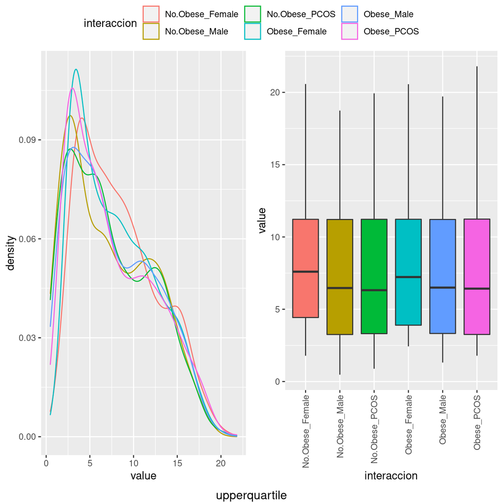

```r
> annotate_figure(p7, bottom = "upperquartile")
```

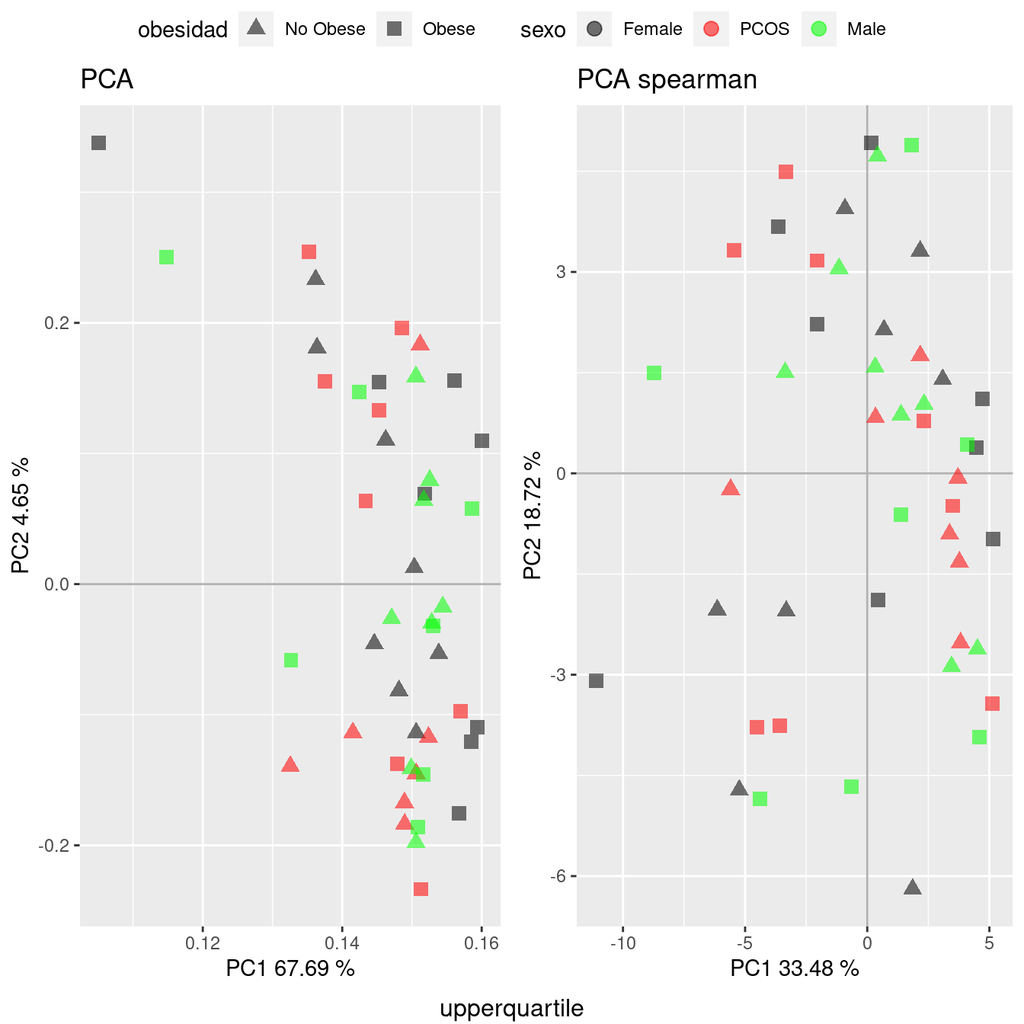

```r
> p8 <- ggarrange(p3, p4, ncol = 2, common.legend = T)
> annotate_figure(p8, bottom = "upperquartile")
```

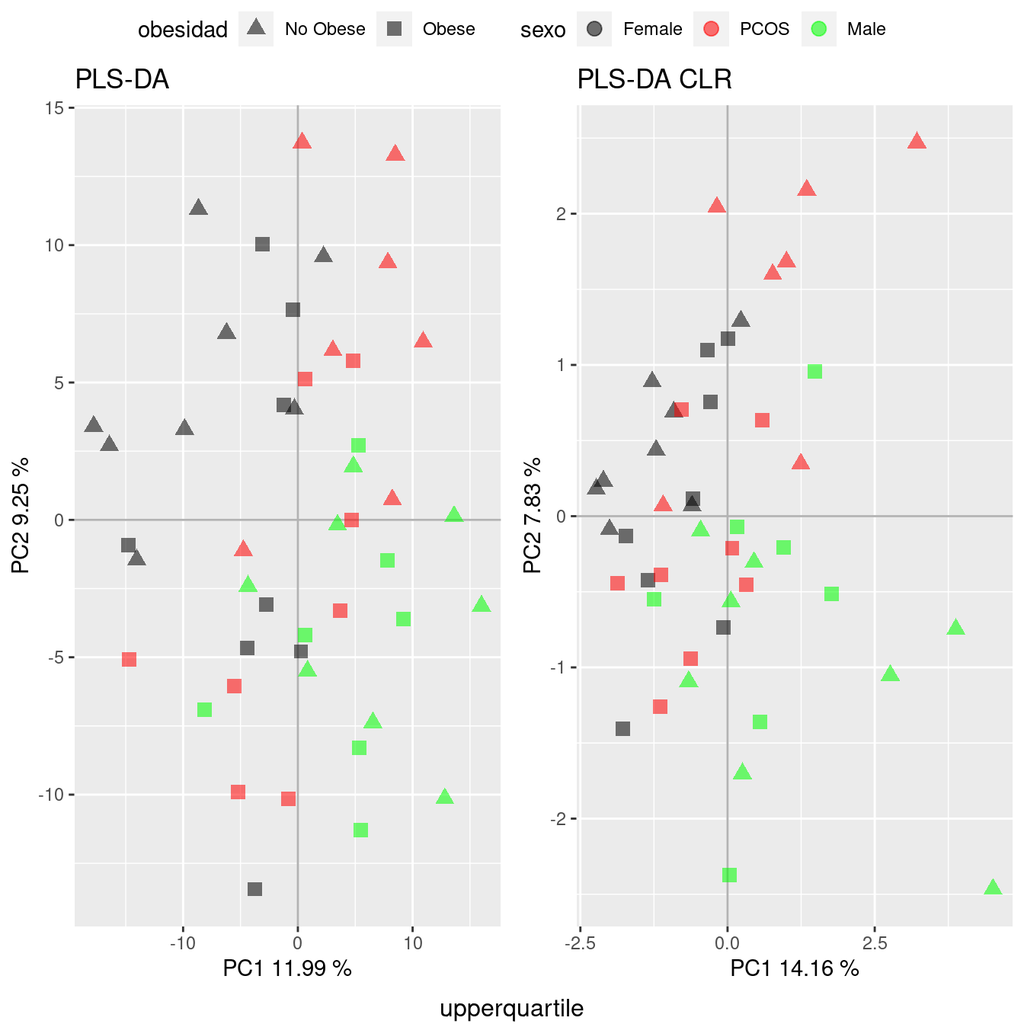

```r
> p9 <- ggarrange(p5, p6, ncol = 2, common.legend = T)
> annotate_figure(p9, bottom = "upperquartile")
```

#### none

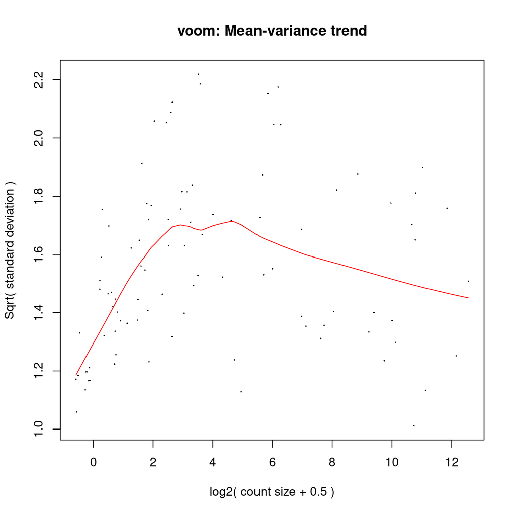

```r
> columnData <- data.frame(interaccion = interaccion)
> rownames(columnData) <- pacientes
> design <- model.matrix(~0 + interaccion)
> dge <- DGEList(counts = t(genus.abs), samples = columnData, group = interaccion)
> nf <- calcNormFactors(dge, refColumn = NULL, method = "none")
> voom.norm.tmm <- voom(nf, plot = T)
> datos <- t(voom.norm.tmm$E)
> p1 <- fn.densidad(datos = datos, fctr = interaccion)
> p2 <- fn.boxplot(datos = datos, fctr = interaccion)
> pca.log <- prcomp(t(datos), center = T, scale. = T)
> pca.var <- 100 * (pca.log$sdev^2/sum(pca.log$sdev^2))
> p3 <- graphPCA.methods(pca.log$rotation[, 1:2], datos.common = datos.common, varianzas = pca.var) +
+     ggtitle("PCA")
> pca.spearman <- princomp(cor(t(datos), method = "spearman"), fix_sign = T, cor = T)
>
> pca.spearman.scores <- pca.spearman$scores
> pca.spearman.var <- 100 * (pca.spearman$sdev^2/sum(pca.spearman$sdev^2))
> p4 <- graphPCA.methods(pca.spearman.scores[, 1:2], datos.common = datos.common, varianzas = pca.spearman.var) +
+     ggtitle("PCA spearman")
>
>
>
> plsda.log <- plsda(datos, Y = interaccion, scale = F)
> plsda.var <- 100 * plsda.log$prop_expl_var$X
> p5 <- graphPCA.methods(datos = plsda.log$variates$X, datos.common = datos.common,
+     varianzas = plsda.var) + ggtitle("PLS-DA")
>
>
>
> plsda.log.clr <- plsda(datos, Y = interaccion, scale = F, logratio = "CLR")
> plsda.log.clr.var <- 100 * plsda.log.clr$prop_expl_var$X
>
> p6 <- graphPCA.methods(datos = plsda.log.clr$variates$X, datos.common = datos.common,
+     varianzas = plsda.log.clr.var) + ggtitle("PLS-DA CLR")
>
>
> p7 <- ggarrange(p1, p2, common.legend = T)
```

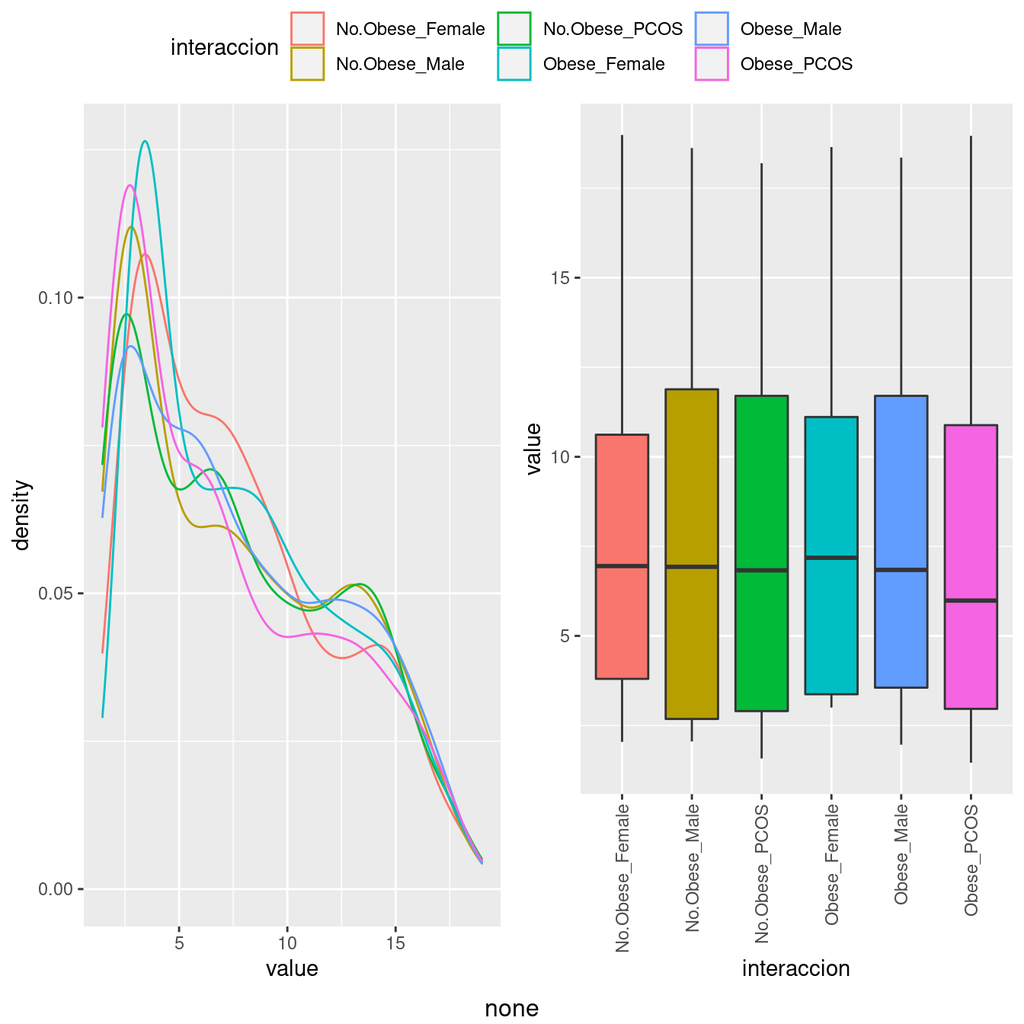

```r
> annotate_figure(p7, bottom = "none")
```

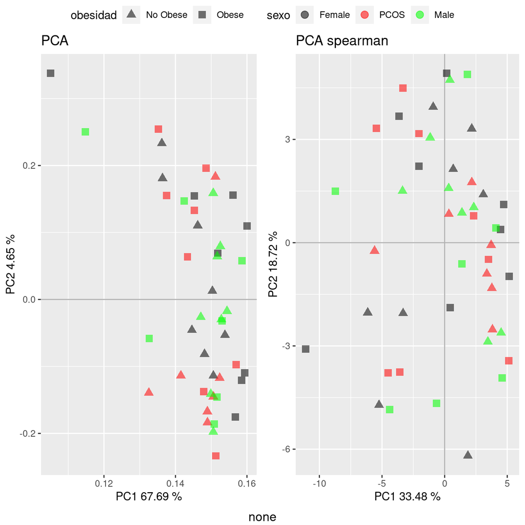

```r
> p8 <- ggarrange(p3, p4, ncol = 2, common.legend = T)
> annotate_figure(p8, bottom = "none")
```

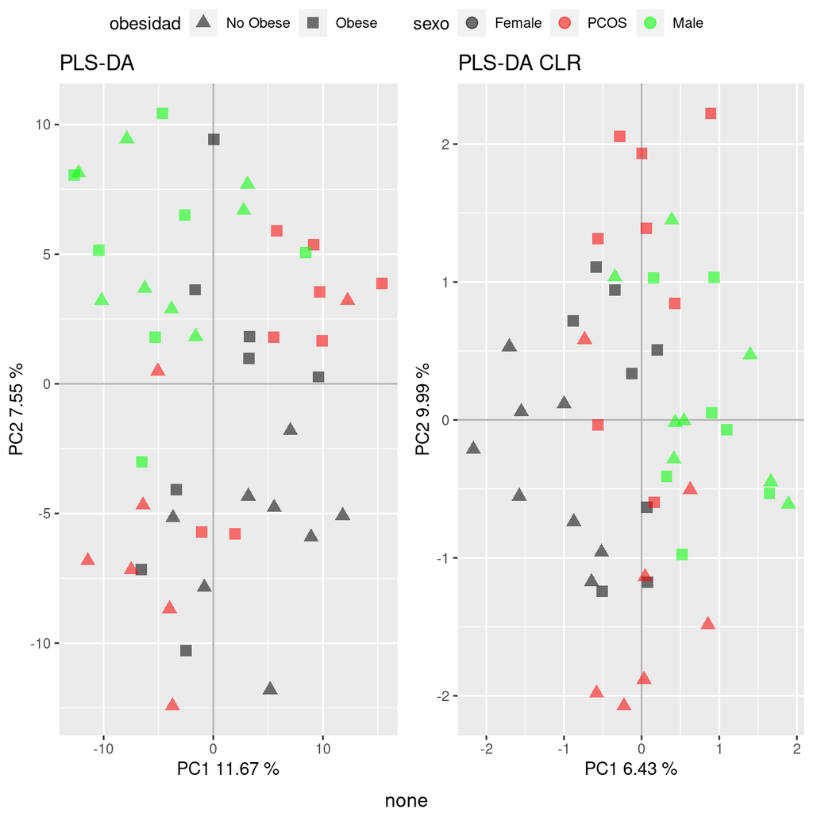

```r
> p9 <- ggarrange(p5, p6, ncol = 2, common.legend = T)
> annotate_figure(p9, bottom = "none")
```